# Homework 4: Decision Trees, Boosting, and Neural Networks

## Decision Tree Implementation

```python
import matplotlib.pyplot as plt
from itertools import product
import numpy as np
from collections import Counter
from sklearn.base import BaseEstimator, RegressorMixin, ClassifierMixin
from sklearn.tree import DecisionTreeClassifier, DecisionTreeRegressor, export_graphviz
from sklearn.ensemble import GradientBoostingClassifier, GradientBoostingRegressor, RandomForestClassifier
# import graphviz
from IPython.display import Image

%matplotlib inline
```

```python
# Load Data
data_train = np.loadtxt('gbm/svm-train.txt')
data_test = np.loadtxt('gbm/svm-test.txt')
x_train, y_train = data_train[:, 0: 2], data_train[:, 2].reshape(-1, 1)
x_test, y_test = data_test[:, 0: 2], data_test[:, 2].reshape(-1, 1)
```

```python
# Change target to 0-1 label
y_train_label = np.array(list(map(lambda x: 1 if x > 0 else 0, y_train))).reshape(-1, 1)
```

1. Complete either the compute entropy or compute gini functions.

```python
def compute_entropy(label_array):
    '''
    Calulate the entropy of given label list

    :param label_array: a numpy array of binary labels shape = (n, 1)
    :return entropy: entropy value
    '''
    labels = np.unique(label_array)
    entropy = 0.
    for label in labels:
        p = np.sum(label_array == label) / label_array.shape[0]
        entropy += -p * np.log(p)
    return entropy

def compute_gini(label_array):
    '''
    Calulate the gini index of label list

    :param label_array: a numpy array of labels shape = (n, 1)
    :return gini: gini index value
    '''
    labels = np.unique(label_array)
    gini = 0.
    for label in labels:
        p = np.sum(label_array == label) / label_array.shape[0]
        gini += p * (1 - p)
    return gini
```

2. Complete the class Decision Tree, given in the skeleton code.

```python
class Decision_Tree(BaseEstimator):

    def __init__(self, split_loss_function, leaf_value_estimator,
                 depth=0, min_sample=5, max_depth=10):
        '''
        Initialize the decision tree classifier

        :param split_loss_function: method with args (X, y) returning loss
        :param leaf_value_estimator: method for estimating leaf value from array of ys
        :param depth: depth indicator, default value is 0, representing root node
        :param min_sample: an internal node can be splitted only if it contains points more than min_smaple
        :param max_depth: restriction of tree depth.
        '''
        self.split_loss_function = split_loss_function
        self.leaf_value_estimator = leaf_value_estimator
        self.depth = depth
        self.min_sample = min_sample
        self.max_depth = max_depth
        self.is_leaf = False

    def fit(self, x, y):
        '''
        This should fit the tree classifier by setting the values self.is_leaf,
        self.split_id (the index of the feature we want ot split on, if we're splitting),
        self.split_value (the corresponding value of that feature where the split is),
        and self.value, which is the prediction value if the tree is a leaf node.  If we are
        splitting the node, we should also init self.left and self.right to be Decision_Tree
        objects corresponding to the left and right subtrees. These subtrees should be fit on
        the data that fall to the left and right,respectively, of self.split_value.
        This is a recurisive tree building procedure.

        :param X: a numpy array of training data, shape = (n, m)
        :param y: a numpy array of labels, shape = (n, 1)

        :return self
        '''
        # Your code goes here
        if self.depth == self.max_depth:
            self.is_leaf = True
            self.value = self.leaf_value_estimator(y)
            return self

        if y.shape[0] <= self.min_sample:
            self.is_leaf = True
            self.value = self.leaf_value_estimator(y)
            return self

        self.find_best_feature_split(x_node=x, y_node=y)
        if self.split_id != None and self.split_value != None:
            self.left = Decision_Tree(self.split_loss_function, self.leaf_value_estimator,
                                       self.depth+1, self.min_sample, self.max_depth)
            self.right = Decision_Tree(self.split_loss_function, self.leaf_value_estimator,
                                       self.depth+1, self.min_sample, self.max_depth)

            x_left = x[x[:, self.split_id] <= self.split_value]
            y_left = y[x[:, self.split_id] <= self.split_value]
            self.left.fit(x_left, y_left)

            x_right = x[x[:, self.split_id] > self.split_value]
            y_right = y[x[:, self.split_id] > self.split_value]
            self.right.fit(x_right, y_right)
        else:
            self.is_leaf = True
            self.value = self.leaf_value_estimator(y)

        return self

    def find_best_split(self, x_node, y_node, feature_id):
        '''
        For feature number feature_id, returns the optimal splitting point
        for data X_node, y_node, and corresponding loss
        :param X: a numpy array of training data, shape = (n_node)
        :param y: a numpy array of labels, shape = (n_node, 1)
        '''
        # Your code
        best_loss = self.split_loss_function(y_node)
        split_value = None

        idx = np.argsort(x_node[:, feature_id])
        x = x_node[idx]
        y = y_node[idx]
        for pos in range(x.shape[0] - 1):
            left_x = x[:pos + 1, :]
            right_x = x[pos + 1:, :]

            left_y = y[:pos + 1, :]
            right_y = y[pos + 1:, :]

            left_loss = left_y.shape[0] * self.split_loss_function(left_y) / y.shape[0]
            right_loss = right_y.shape[0] * self.split_loss_function(right_y) / y.shape[0]

            if (left_loss + right_loss < best_loss):
                split_value = x[pos, feature_id]
                best_loss = left_loss + right_loss
        return split_value, best_loss

    def find_best_feature_split(self, x_node, y_node):
        '''
        Returns the optimal feature to split and best splitting point
        for data X_node, y_node.
        :param X: a numpy array of training data, shape = (n_node, 1)
        :param y: a numpy array of labels, shape = (n_node, 1)
        '''

        self.split_id = None
        self.split_value = None
        best_loss = None
        for i in range(x_node.shape[1]):
            split_value, loss = self.find_best_split(x_node, y_node, i)
            if (best_loss == None or loss < best_loss):
                best_loss = loss
                self.split_value = split_value
                self.split_id = i


    def predict_instance(self, instance):
        '''
        Predict label by decision tree

        :param instance: a numpy array with new data, shape (1, m)

        :return whatever is returned by leaf_value_estimator for leaf containing instance
        '''
        if self.is_leaf:
            return self.value
        if instance[self.split_id] <= self.split_value:
            return self.left.predict_instance(instance)
        else:
            return self.right.predict_instance(instance)
```

```python
def most_common_label(y):
    '''
    Find most common label
    '''
    label_cnt = Counter(y.reshape(len(y)))
    label = label_cnt.most_common(1)[0][0]
    return label
```

```python
class Classification_Tree(BaseEstimator, ClassifierMixin):

    loss_function_dict = {
        'entropy': compute_entropy,
        'gini': compute_gini
    }

    def __init__(self, loss_function='gini', min_sample=5, max_depth=10):
        '''
        :param loss_function(str): loss function for splitting internal node
        '''
        self.loss_function = self.loss_function_dict[loss_function]
        self.max_depth = max_depth
        self.min_sample = min_sample
        self.tree = Decision_Tree(self.loss_function_dict[loss_function],
                                most_common_label,
                                0, min_sample, max_depth)

    def fit(self, X, y=None):
        self.tree.fit(X,y)
        return self

    def predict_instance(self, instance):
        value = self.tree.predict_instance(instance)
        return value
```

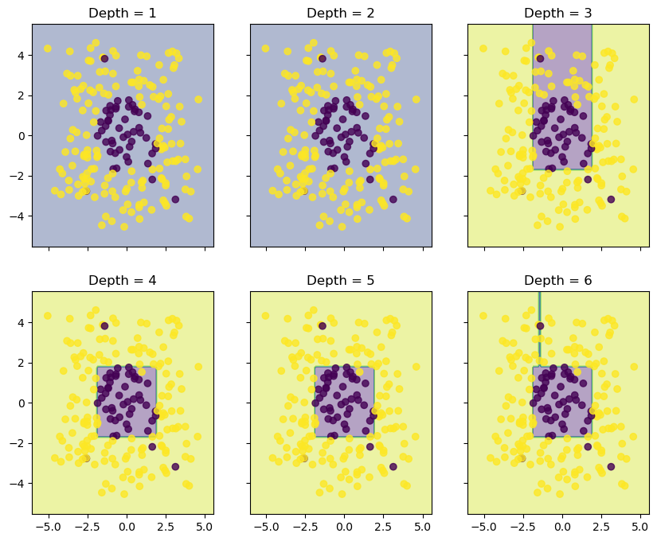

```python
# Training classifiers with different depth
clf1 = Classification_Tree(max_depth=1, min_sample=2)
clf1.fit(x_train, y_train_label)

clf2 = Classification_Tree(max_depth=2, min_sample=2)
clf2.fit(x_train, y_train_label)

clf3 = Classification_Tree(max_depth=3, min_sample=2)
clf3.fit(x_train, y_train_label)

clf4 = Classification_Tree(max_depth=4, min_sample=2)
clf4.fit(x_train, y_train_label)

clf5 = Classification_Tree(max_depth=5, min_sample=2)
clf5.fit(x_train, y_train_label)

clf6 = Classification_Tree(max_depth=6, min_sample=2)
clf6.fit(x_train, y_train_label)

# Plotting decision regions
x_min, x_max = x_train[:, 0].min() - 1, x_train[:, 0].max() + 1
y_min, y_max = x_train[:, 1].min() - 1, x_train[:, 1].max() + 1
xx, yy = np.meshgrid(np.arange(x_min, x_max, 0.1),
                     np.arange(y_min, y_max, 0.1))

f, axarr = plt.subplots(2, 3, sharex='col', sharey='row', figsize=(10, 8))

for idx, clf, tt in zip(product([0, 1], [0, 1, 2]),
                        [clf1, clf2, clf3, clf4, clf5, clf6],
                        ['Depth = {}'.format(n) for n in range(1, 7)]):

    Z = np.array([clf.predict_instance(x) for x in np.c_[xx.ravel(), yy.ravel()]])
    Z = Z.reshape(xx.shape)

    axarr[idx[0], idx[1]].contourf(xx, yy, Z, alpha=0.4)
    axarr[idx[0], idx[1]].scatter(x_train[:, 0], x_train[:, 1], c=y_train_label[:,0], alpha=0.8)
    axarr[idx[0], idx[1]].set_title(tt)

plt.show()
```

```python
clf = DecisionTreeClassifier(criterion='entropy', max_depth=3, min_samples_split=5)
clf.fit(x_train, y_train_label)
export_graphviz(clf, out_file='tree_classifier.dot')
```

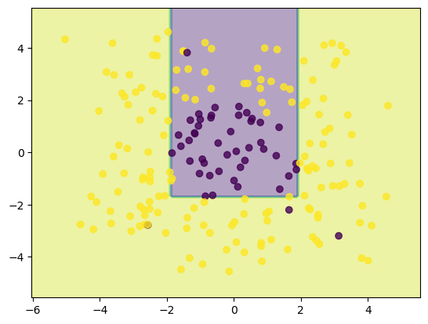

```python
# Plotting decision regions
x_min, x_max = x_train[:, 0].min() - 1, x_train[:, 0].max() + 1
y_min, y_max = x_train[:, 1].min() - 1, x_train[:, 1].max() + 1
xx, yy = np.meshgrid(np.arange(x_min, x_max, 0.1),
                     np.arange(y_min, y_max, 0.1))

Z = np.array([clf.predict(x[np.newaxis,:]) for x in np.c_[xx.ravel(), yy.ravel()]])
Z = Z.reshape(xx.shape)
plt.figure()
plt.contourf(xx, yy, Z, alpha=0.4)
plt.scatter(x_train[:, 0], x_train[:, 1],
c=y_train_label[:,0], alpha=0.8)
```

3. Run the code provided that builds trees for the two-dimensional classiﬁcation data. Include the results. For debugging, you may want to compare results with sklearn's decision tree (code provided in the skeleton code). For visualization, you'll need to install `graphviz`.

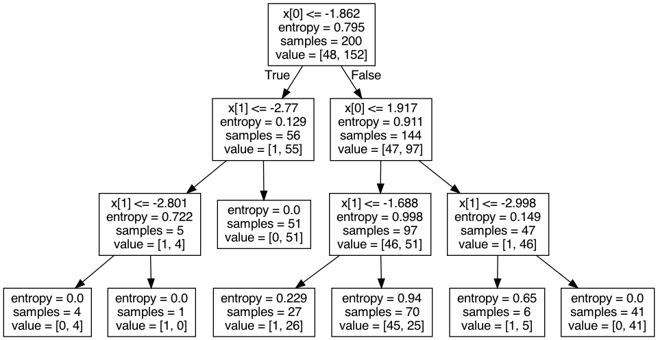

```python
# Visualize decision tree
!dot -Tpng tree_classifier.dot -o tree_classifier.png
Image(filename='tree_classifier.png')
```

4. Complete the function mean absolute deviation around median (MAE). Use the code provided to fit the Regression Tree to the krr dataset using both the MAE loss and median predictions. Include the plots for the 6 fits.

```python
# Regression Tree Specific Code
def mean_absolute_deviation_around_median(y):
    '''
    Calulate the mean absolute deviation around the median of a given target list

    :param y: a numpy array of targets shape = (n, 1)
    :return mae
    '''
    mean = np.median(y)
    mae = np.mean(np.abs(y - mean))
    return mae
```

```python
class Regression_Tree():
    '''
    :attribute loss_function_dict: dictionary containing the loss functions used for splitting
    :attribute estimator_dict: dictionary containing the estimation functions used in leaf nodes
    '''

    loss_function_dict = {
        'mse': np.var,
        'mae': mean_absolute_deviation_around_median
    }

    estimator_dict = {
        'mean': np.mean,
        'median': np.median
    }

    def __init__(self, loss_function='mse', estimator='mean', min_sample=5, max_depth=10):
        '''
        Initialize Regression_Tree
        :param loss_function(str): loss function used for splitting internal nodes
        :param estimator(str): value estimator of internal node
        '''

        self.tree = Decision_Tree(self.loss_function_dict[loss_function],
                                  self.estimator_dict[estimator],
                                  0, min_sample, max_depth)

    def fit(self, X, y=None):
        self.tree.fit(X,y)
        return self

    def predict_instance(self, instance):
        value = self.tree.predict_instance(instance)
        return value
```

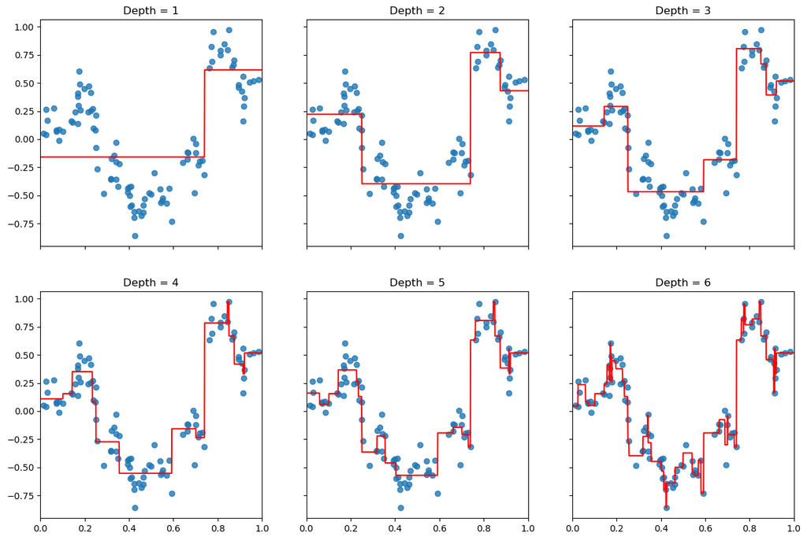

```python
data_krr_train = np.loadtxt('gbm/krr-train.txt')
data_krr_test = np.loadtxt('gbm/krr-test.txt')
x_krr_train, y_krr_train = data_krr_train[:,0].reshape(-1,1),data_krr_train[:,1].reshape(-1,1)
x_krr_test, y_krr_test = data_krr_test[:,0].reshape(-1,1),data_krr_test[:,1].reshape(-1,1)

# Training regression trees with different depth
clf1 = Regression_Tree(max_depth=1,  min_sample=3, loss_function='mae', estimator='mean')
clf1.fit(x_krr_train, y_krr_train)

clf2 = Regression_Tree(max_depth=2,  min_sample=3, loss_function='mae', estimator='mean')
clf2.fit(x_krr_train, y_krr_train)

clf3 = Regression_Tree(max_depth=3,  min_sample=3, loss_function='mae', estimator='mean')
clf3.fit(x_krr_train, y_krr_train)

clf4 = Regression_Tree(max_depth=4,  min_sample=3, loss_function='mae', estimator='mean')
clf4.fit(x_krr_train, y_krr_train)

clf5 = Regression_Tree(max_depth=5,  min_sample=3, loss_function='mae', estimator='mean')
clf5.fit(x_krr_train, y_krr_train)

clf6 = Regression_Tree(max_depth=10,  min_sample=3, loss_function='mae', estimator='mean')
clf6.fit(x_krr_train, y_krr_train)

plot_size = 0.001
x_range = np.arange(0., 1., plot_size).reshape(-1, 1)

f2, axarr2 = plt.subplots(2, 3, sharex='col', sharey='row', figsize=(15, 10))

for idx, clf, tt in zip(product([0, 1], [0, 1, 2]),
                        [clf1, clf2, clf3, clf4, clf5, clf6],
                        ['Depth = {}'.format(n) for n in range(1, 7)]):

    y_range_predict = np.array([clf.predict_instance(x) for x in x_range]).reshape(-1, 1)

    axarr2[idx[0], idx[1]].plot(x_range, y_range_predict, color='r')
    axarr2[idx[0], idx[1]].scatter(x_krr_train, y_krr_train, alpha=0.8)
    axarr2[idx[0], idx[1]].set_title(tt)
    axarr2[idx[0], idx[1]].set_xlim(0, 1)
plt.show()
```

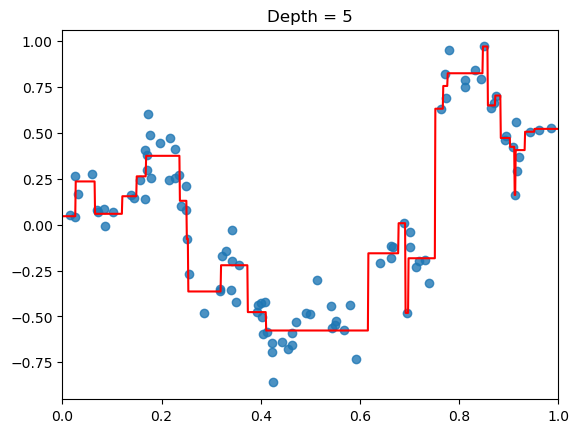

```python
# Compare with sklearn
plot_size = 0.001
x_range = np.arange(0., 1., plot_size).reshape(-1, 1)
max_depth = 5

clf = DecisionTreeRegressor(criterion='squared_error', max_depth=max_depth, min_samples_split=3)
clf.fit(x_krr_train, y_krr_train)
export_graphviz(clf, out_file='tree_classifier.dot')

y_range_predict = np.array([clf.predict(x[np.newaxis,:]) for x in x_range]).reshape(-1, 1)

plt.plot(x_range, y_range_predict, color='r')
plt.scatter(x_krr_train, y_krr_train, alpha=0.8)
plt.title('Depth = {}'.format(max_depth))
plt.xlim(0, 1)
plt.show()
```

## Ensembling

### Gradient Boosting Regression Implementation

5. Complete the gradient boosting class.

```python
#Pseudo-residual function.

def pseudo_residual_L2(train_target, train_predict):
    '''
    Compute the pseudo-residual based on current predicted value.
    '''
    return train_target - train_predict
```

```python
class gradient_boosting():
    '''
    Gradient Boosting regressor class
    :method fit: fitting model
    '''
    def __init__(self, n_estimator, pseudo_residual_func, learning_rate=0.01,
                 min_sample=5, max_depth=5):
        '''
        Initialize gradient boosting class

        :param n_estimator: number of estimators (i.e. number of rounds of gradient boosting)
        :pseudo_residual_func: function used for computing pseudo-residual between training labels and predicted labels at each iteration
        :param learning_rate: step size of gradient descent
        '''
        self.n_estimator = n_estimator
        self.pseudo_residual_func = pseudo_residual_func
        self.learning_rate = learning_rate
        self.min_sample = min_sample
        self.max_depth = max_depth

        self.estimators = [] #will collect the n_estimator models

    def fit(self, train_data, train_target):
        '''
        Fit gradient boosting model
        :train_data array of inputs of size (n_samples, m_features)
        :train_target array of outputs of size (n_samples,)
        '''
        train_predict = np.zeros(train_target.shape)
        for m in range(self.n_estimator):
            estimator = DecisionTreeRegressor(criterion='squared_error',
                                        max_depth=self.max_depth,
                                        min_samples_split=self.min_sample)
            pseudo_residuals = self.pseudo_residual_func(train_target, train_predict)
            estimator.fit(train_data, pseudo_residuals)

            train_predict += self.learning_rate * estimator.predict(train_data)
            self.estimators.append(estimator)

    def predict(self, test_data):
        '''
        Predict value
        :train_data array of inputs of size (n_samples, m_features)
        '''
        test_predict = np.zeros(test_data.shape[0])
        for estimator in self.estimators:
            test_predict += self.learning_rate * estimator.predict(test_data)
        return test_predict
```

6. Run the code provided to build gradient boosting models on the regression data sets krr-train.txt, and include the plots generated. For debugging you can use the sklearn implementation of GradientBoostingRegressor.

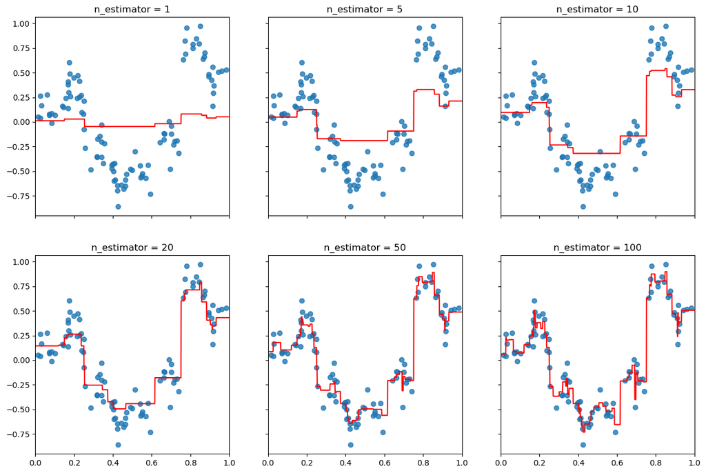

```python
plot_size = 0.001
x_range = np.arange(0., 1., plot_size).reshape(-1, 1)

f2, axarr2 = plt.subplots(2, 3, sharex='col', sharey='row', figsize=(15, 10))

for idx, i, tt in zip(product([0, 1], [0, 1, 2]),
                       [1, 5, 10, 20, 50, 100],
                       ['n_estimator = {}'.format(n) for n in [1, 5, 10, 20, 50, 100]]):

    gbm_1d = gradient_boosting(n_estimator=i, pseudo_residual_func=pseudo_residual_L2,
                               max_depth=3, learning_rate=0.1)
    gbm_1d.fit(x_krr_train, y_krr_train[:,0])

    y_range_predict = gbm_1d.predict(x_range)

    axarr2[idx[0], idx[1]].plot(x_range, y_range_predict, color='r')
    axarr2[idx[0], idx[1]].scatter(x_krr_train, y_krr_train, alpha=0.8)
    axarr2[idx[0], idx[1]].set_title(tt)
    axarr2[idx[0], idx[1]].set_xlim(0, 1)
```

## Ridge Regression

7. Complete the class `L2NormPenaltyNode` in `nodes.py`. If your code is correct, you should be able to pass test `L2NormPenaltyNode` in ridge `regression.t.py`. Please attach a screenshot that shows the test results for this question.

```python
class L2NormPenaltyNode(object):
    """ Node computing l2_reg * ||w||^2 for scalars l2_reg and vector w"""
    def __init__(self, l2_reg, w, node_name):
        """
        Parameters:
        l2_reg: a numpy scalar array (e.g. np.array(.01)) (not a node)
        w: a node for which w.out is a numpy vector
        node_name: node's name (a string)
        """
        self.node_name = node_name
        self.out = None
        self.d_out = None
        self.l2_reg = np.array(l2_reg)
        self.w = w

    def forward(self):
        self.out = self.l2_reg * np.dot(self.w.out, self.w.out)
        self.d_out = np.zeros(self.out.shape)
        return self.out

    def backward(self):
        d_w = self.d_out * 2 * self.l2_reg * self.w.out
        self.w.d_out += d_w
        return self.d_out

    def get_predecessors(self):
        return [self.w]
```

The result of runing `ridge_regression.t.py` is:

[figure not shown]

As shown in the picture, the `test_L2NormPenaltyNode` has passed, the 2 errors are because of the failure of `test_SumNode` and `test_ridge_regression_gradient`

8. Complete the class `SumNode` in `nodes.py`. If your code is correct, you should be able to pass test `SumNode` in `ridge_regression.t.py`. Please attach a screenshot that shows the test results for this question.

```python
class SumNode(object):
    """ Node computing a + b, for numpy arrays a and b"""
    def __init__(self, a, b, node_name):
        """
        Parameters:
        a: node for which a.out is a numpy array
        b: node for which b.out is a numpy array of the same shape as a
        node_name: node's name (a string)
        """
        self.node_name = node_name
        self.out = None
        self.d_out = None
        self.b = b
        self.a = a

    def forward(self):
        self.out = self.a.out + self.b.out
        self.d_out = np.zeros(self.out.shape)
        return self.out

    def backward(self):
        d_a = self.d_out
        d_b = self.d_out
        self.a.d_out += d_a
        self.b.d_out += d_b
        return self.d_out

    def get_predecessors(self):
        return [self.a, self.b]
```

The result of runing `ridge_regression.t.py` is:

[figure not shown]

As shown in the picture, the `test_SumNode` has passed, the remaining error is because of the failure of `test_ridge_regression_gradient`

9. Implement ridge regression with w regularized and b unregularized. Do this by completing the init method in ridge regression.py, using the classes created above. When complete, you should be able to pass the tests in ridge regression.t.py. Report the average square error on the training set for the parameter settings given in the main() function.

```python
class LinearRegression(BaseEstimator, RegressorMixin):
    """ Linear regression with computation graph """
    def __init__(self, step_size=.005,  max_num_epochs = 5000):
        self.max_num_epochs = max_num_epochs
        self.step_size = step_size

        # Build computation graph
        self.x = nodes.ValueNode(node_name="x") # to hold a vector input
        self.y = nodes.ValueNode(node_name="y") # to hold a scalar response
        self.w = nodes.ValueNode(node_name="w") # to hold the parameter vector
        self.b = nodes.ValueNode(node_name="b") # to hold the bias parameter (scalar)
        self.prediction = nodes.VectorScalarAffineNode(x=self.x, w=self.w, b=self.b,
                                                 node_name="prediction")
        self.objective = nodes.SquaredL2DistanceNode(a=self.prediction, b=self.y,
                                               node_name="square loss")

        # Group nodes into types to construct computation graph function
        self.inputs = [self.x]
        self.outcomes = [self.y]
        self.parameters = [self.w, self.b]

        self.graph = graph.ComputationGraphFunction(self.inputs, self.outcomes,
                                                          self.parameters, self.prediction,
                                                          self.objective)
```

```python
!cd nn && python ridge_regression.py
```

```
Epoch  0 : Ave objective= 1.6108114728833893  Ave training loss:  0.814451202030029
Epoch  50 : Ave objective= 0.326471995066246  Ave training loss:  0.24374056233158115
Epoch  100 : Ave objective= 0.31643936628363606  Ave training loss:  0.2119223585218405
Epoch  150 : Ave objective= 0.313966270094773  Ave training loss:  0.20339795967519522
Epoch  200 : Ave objective= 0.313115373707523  Ave training loss:  0.20018761369883634
Epoch  250 : Ave objective= 0.31268803485155133  Ave training loss:  0.19865057290452615
Epoch  300 : Ave objective= 0.31201635718741216  Ave training loss:  0.19908744057118377
Epoch  350 : Ave objective= 0.3117891246135745  Ave training loss:  0.19752035261429896
Epoch  400 : Ave objective= 0.3115211165415517  Ave training loss:  0.1973655969831973
Epoch  450 : Ave objective= 0.31040356418666915  Ave training loss:  0.19748689211663012
Epoch  500 : Ave objective= 0.3107746238692324  Ave training loss:  0.1975357525627485
Epoch  550 : Ave objective= 0.31109935884120044  Ave training loss:  0.19816439091917576
Epoch  600 : Ave objective= 0.3096907280733527  Ave training loss:  0.19790782516065472
Epoch  650 : Ave objective= 0.30909673004426097  Ave training loss:  0.19783147839208237
Epoch  700 : Ave objective= 0.30927419819762764  Ave training loss:  0.19772307719011917
Epoch  750 : Ave objective= 0.3071001334667472  Ave training loss:  0.19951763188601998
Epoch  800 : Ave objective= 0.3084849686909121  Ave training loss:  0.19769154370616754
Epoch  850 : Ave objective= 0.30838916364390473  Ave training loss:  0.1978992341933867
Epoch  900 : Ave objective= 0.3079846055244204  Ave training loss:  0.19825579704359358
Epoch  950 : Ave objective= 0.3070633383917244  Ave training loss:  0.1981533441710535
Epoch  1000 : Ave objective= 0.3068020660398805  Ave training loss:  0.1996097935221254
Epoch  1050 : Ave objective= 0.3053943167071163  Ave training loss:  0.19859002602379014
Epoch  1100 : Ave objective= 0.3070443000000572  Ave training loss:  0.19831936886570228
Epoch  1150 : Ave objective= 0.30737288878361346  Ave training loss:  0.19831254888137959
Epoch  1200 : Ave objective= 0.30655537354529944  Ave training loss:  0.19849631191359127
Epoch  1250 : Ave objective= 0.30708650683329797  Ave training loss:  0.1986909325130772
Epoch  1300 : Ave objective= 0.3067177987504828  Ave training loss:  0.19883309897228862
Epoch  1350 : Ave objective= 0.3062309129081774  Ave training loss:  0.19973599994404373
Epoch  1400 : Ave objective= 0.30596554504860646  Ave training loss:  0.19931070753645388
Epoch  1450 : Ave objective= 0.30538013600236086  Ave training loss:  0.19908191722549465
Epoch  1500 : Ave objective= 0.30551978921479805  Ave training loss:  0.19897417577400842
Epoch  1550 : Ave objective= 0.3056152427262834  Ave training loss:  0.19875349764078454
Epoch  1600 : Ave objective= 0.30469846866739886  Ave training loss:  0.1994570459294766
Epoch  1650 : Ave objective= 0.30387370325425506  Ave training loss:  0.20191589049464911
Epoch  1700 : Ave objective= 0.3052419346077282  Ave training loss:  0.19918299465819408
Epoch  1750 : Ave objective= 0.3052018451493371  Ave training loss:  0.19939755933008654
Epoch  1800 : Ave objective= 0.3053098145965909  Ave training loss:  0.1992840237550494
Epoch  1850 : Ave objective= 0.30520229363718254  Ave training loss:  0.19973343914551406
Epoch  1900 : Ave objective= 0.30509459721171717  Ave training loss:  0.1993303515682506
Epoch  1950 : Ave objective= 0.30453305349354765  Ave training loss:  0.19955834713001117
Epoch  0 : Ave objective= 0.7030565835970036  Ave training loss:  0.5122347052134655
Epoch  50 : Ave objective= 0.12515529689250518  Ave training loss:  0.10667846468121138
Epoch  100 : Ave objective= 0.10201560992357571  Ave training loss:  0.0847313131614699
Epoch  150 : Ave objective= 0.08379338762710481  Ave training loss:  0.08615250246625013
Epoch  200 : Ave objective= 0.07522216908946518  Ave training loss:  0.06395353134507832
Epoch  250 : Ave objective= 0.06621943976585348  Ave training loss:  0.07059614020120218
Epoch  300 : Ave objective= 0.06452538348038138  Ave training loss:  0.060765081870377165
Epoch  350 : Ave objective= 0.05974285825273352  Ave training loss:  0.050003720832822764
Epoch  400 : Ave objective= 0.05575076462283444  Ave training loss:  0.04530531880617089
Epoch  450 : Ave objective= 0.05143403697429739  Ave training loss:  0.04234567682820479
Figure(640x480)
```

[figure not shown]

## Multilayer Perceptron

### The standard non-linear layer

#### The Aﬃne Transformation

In a general neural network, there may be quite a lot of computation between any given affine transformation $Wx + b$ and the final objective function value $J$. We will capture all of that in a function $f : \mathbb{R}^m \rightarrow \mathbb{R}$, for which $J = f(Wx + b)$. Our goal is to find the partial derivative of $J$ with respect to each element of $W$, namely $\frac{\partial J}{\partial W_{ij}}$, as well as the partials $\frac{\partial J}{\partial b_i}$, for each element of $b$. For convenience, let $y = Wx + b$, so we can write $J = f(y)$. Suppose we have already computed the partial derivatives of $J$ with respect to the entries of $y = (y_i, ..., y_m)^T$, namely $\frac {\partial{J}}{\partial{y_i}}$ for $i = 1, ..., m$. Then by the chain rule, we have $$\frac {\partial{J}}{\partial{W_{ij}}} = \sum^m_{r = 1} \frac{\partial{J}}{\partial{y_r}} \frac{\partial{y_r}}{\partial{W_{ij}}}$$

10. Show that $ \frac{\partial J}{\partial W_{ij}} = \frac{\partial J}{\partial y_i} x_j, $ where $x = (x_1, \ldots, x_d)^T$. [Hint: Although not necessary, you might find it helpful to use the notation $\delta_{ij}$ which is defined as $ \delta_{ij} = \begin{cases} 1 & i = j \\ 0 & \text{else} \end{cases} $ So, for example, $\partial_{x_i} (\sum_{i=1}^{n} x_i^2) = 2x_i\delta_{ij} = 2x_j$.]

$$ \begin{aligned} \frac {\partial{J}} {\partial{W_{ij}}} &= \sum^m_{r = 1} \frac{\partial{J}}{\partial{y_r}} \frac{\partial{y_r}}{\partial{W_{ij}}} \\ &= \sum^m_{r = 1} \frac{\partial{J}}{\partial{y_r}} \frac{\partial{y_r}}{\partial{W_{ij}}} \delta_{ir} \\ &= \frac{\partial{J}}{\partial{y_i}} \frac{\partial{y_i}}{\partial{W_{ij}}} \\ &= \frac{\partial J}{\partial y_i} x_j \end{aligned} $$

11. Now let's vectorize this. Let's write $\frac{\partial J}{\partial \mathbf{y}} \in \mathbb{R}^{m \times 1}$ for the column vector whose $i$ th entry is $\frac{\partial J}{\partial y_i}$. Let's also define the matrix $\frac {\partial J}{\partial \mathbf{W}} \in \mathbb{R}^{m \times d}$, whose $ij$ th entry is $\frac{\partial J}{\partial W_{ij}}$. Generally speaking, we'll always take $\frac{\partial J}{\partial A}$ to be an array of the same size ("shape" in numpy) as $A$. Give a vectorized expression for $\frac{\partial J}{\partial \mathbf{W}}$ in terms of the column vectors $\frac{\partial J}{\partial \mathbf{y}}$ and $x$. [Hint: Outer product.]

As shown in the previous problem

$$\frac{\partial J}{\partial W_{ij}} = \frac{\partial J}{\partial y_i} x_j$$$$(\frac{\partial{J}}{\partial{W}})_{ij} = (\frac{\partial{J}}{\partial{y}})_i x_j = (\frac{\partial{J}}{\partial{y}} \otimes x)_{ij}$$

which is

$$\frac{\partial J}{\partial W} = \frac{\partial{J}}{\partial{y}} \otimes x$$

12. In the usual way, define $\frac{\partial J}{\partial \mathbf{x}} \in \mathbb{R}^d$, whose $i$ th entry is $\frac{\partial J}{\partial x_i}$. Show that

$$ \frac{\partial J}{\partial \mathbf{x}} = W^T \left( \frac{\partial J}{\partial \mathbf{y}} \right) $$

[Note, if $\mathbf{x}$ is just data, technically we won't need this derivative. However, in a multilayer perceptron, $x$ may actually be the output of a previous hidden layer, in which case we will need to propagate the derivative through $x$ as well.]

for single $x_i$,

$$ \begin{aligned} \frac{\partial{J}}{\partial{x_i}} &= \sum^m_{k = 1} \frac{\partial{J}}{\partial{y_k}} \frac{\partial{y_k}}{\partial{x_i}} \\ &= \sum^m_{k = 1} \frac{\partial{J}}{\partial{y_k}} W_{ki} \end{aligned} $$

which is

$$\frac{\partial{J}}{\partial{x}} = \frac{\partial{J}}{\partial{y}} \frac{\partial{y}}{\partial{x}} = W^T (\frac{\partial{J}}{\partial{y}})$$

13. show that $\frac{\partial{J}}{\partial{b}} = \frac{\partial{J}}{\partial{y}}$, where $\frac{\partial{J}}{\partial{b}}$ is defined in the usual way.

$$\frac{\partial{J}}{\partial{b}} = \frac{\partial{J}}{\partial{y}} \frac{\partial{y}}{\partial{b}}$$

As

$$\frac{\partial{y}}{\partial{b}} = I$$

which means that

$$\frac{\partial{J}}{\partial{y}} \frac{\partial{y}}{\partial{b}} = \frac{\partial{J}}{\partial{y}} I = \frac{\partial{J}}{\partial{y}}$$

### Element-wise Transformers

14. show that $\frac{\partial J}{\partial \mathbf{A}} = \frac{\partial J}{\partial \mathbf{S}} \odot \sigma'(A)$, where we’re using $\odot$ to represent the Hadamard product. If A and B are arrays of the same shape, then their Hadamard product $A \odot B$ is an array with the same shape as $A$ and $B$, and for which $(A \odot B)_i = A_iB_i$. That is, it’s just the array formed by multiplying corresponding elements of $A$ and $B$. Conveniently, in numpy if `A` and `B` are arrays of the same shape, then `A*B` is their Hadamard product.

For a single $A_i$,

$$\frac{\partial{J}}{\partial{A_i}} = \frac{\partial{J}}{\partial{S_i}} \frac{\partial{S_i}}{\partial{A_i}} = \frac{\partial{J}}{\partial{S_i}} \sigma'(A_i)$$

So, for any i, there is

$$(\frac{\partial{J}}{\partial{A}})_i = (\frac{\partial{J}}{\partial{S}})_i (\sigma'(A))_i = (\frac{\partial J}{\partial \mathbf{S}} \odot \sigma'(A))_i$$

Which is

$$\frac{\partial J}{\partial \mathbf{A}} = \frac{\partial J}{\partial \mathbf{S}} \odot \sigma'(A)$$

## MLP Implementation

15. Complete the class `AffineNode` in `nodes.py`. Be sure to propagate the gradient with respect to x as well, since when we stack these layers, x will itself be the output of another node that depends on our optimization parameters. If your code is correct, you should be able to pass test `AffineNode` in `mlp_regression.t.py`. Please attach a screenshot that shows the test results for this question.

```python
class AffineNode(object):
    """Node implementing affine transformation (W,x,b)-->Wx+b, where W is a matrix,
    and x and b are vectors
        Parameters:
        W: node for which W.out is a numpy array of shape (m,d)
        x: node for which x.out is a numpy array of shape (d)
        b: node for which b.out is a numpy array of shape (m) (i.e. vector of length m)
    """
    # Your code
    def __init__(self, W, x, b, node_name):
        self.node_name = node_name
        self.W = W
        self.x = x
        self.b = b
        self.out = None
        self.d_out = None

    def forward(self):
        self.out = np.dot(self.W.out, self.x.out) + self.b.out
        self.d_out = np.zeros(self.out.shape)
        return self.out

    def backward(self):
        d_W = np.outer(self.d_out, self.x.out).reshape(self.W.d_out.shape)
        d_x = np.dot(self.W.out.T, self.d_out)
        d_b = self.d_out
        self.W.d_out += d_W
        self.x.d_out += d_x
        self.b.d_out += d_b
        return self.d_out

    def get_predecessors(self):
        return [self.W, self.x, self.b]
```

The result of runing `mlp_regression.t.py` is:

[figure not shown]

As shown in the picture, the `test_AffineNode` has passed, the remaining errors is because of the failure of the other two tests.

16. Complete the class `TanhNode` in nodes.py. As you’ll recall, $\frac{d}{dx} \tanh(x) = 1 - \tanh^2 x$. Note that in the forward pass, we’ll already have computed tanh of the input and stored it in self.out. So make sure to use self.out and not recalculate it in the backward pass. If your code is correct, you should be able to pass test TanhNode in `mlp_regression.t.py`. Please attach a screenshot that shows the test results for this question.

```python
class TanhNode(object):
    """Node tanh(a), where tanh is applied elementwise to the array a
        Parameters:
        a: node for which a.out is a numpy array
    """
    def __init__(self, a, node_name):
        self.node_name = node_name
        self.a = a
        self.out = None
        self.d_out = None

    def forward(self):
        self.out = np.tanh(self.a.out)
        self.d_out = np.zeros(self.out.shape)
        return self.out

    def backward(self):
        d_a = self.d_out * (1 - self.out ** 2)
        self.a.d_out += d_a
        return self.d_out

    def get_predecessors(self):
        return [self.a]
```

The result of runing `mlp_regression.t.py` is:

[figure not shown]

As shown in the picture, the `test_TanhNode` has passed, the remaining error is because of the failure of the `test_mlp_regression_gradient`.

17. Implement an MLP by completing the skeleton code in `mlp_regression.py` and making use of the nodes above. Your code should pass the tests provided in `mlp_regression.t.py`. Note that to break the symmetry of the problem, we initialize our weights to small random values, rather than all zeros, as we often do for convex optimization problems. Run the MLP for the two settings given in the `main()` function and report the average training error. Note that with an MLP, we can take the original scalar as input, in the hopes that it will learn nonlinear features on its own, using the hidden layers. In practice, it is quite challenging to get such a neural network to ﬁt as well as one where we provide features.

```python
class MLPRegression(BaseEstimator, RegressorMixin):
    """ MLP regression with computation graph """
    def __init__(self, num_hidden_units=10, step_size=.005, init_param_scale=0.01, max_num_epochs = 5000):
        self.num_hidden_units = num_hidden_units
        self.init_param_scale = init_param_scale
        self.max_num_epochs = max_num_epochs
        self.step_size = step_size

        # Your code
        self.x = nodes.ValueNode("x")
        self.y = nodes.ValueNode("y")

        self.W1 = nodes.ValueNode("W1")
        self.b1 = nodes.ValueNode("b1")
        self.w2 = nodes.ValueNode("w2")
        self.b2 = nodes.ValueNode("b2")

        self.affine = nodes.AffineNode(self.W1, self.x, self.b1, "affine")
        self.tanh = nodes.TanhNode(self.affine, "hidden tanh")
        self.prediction = nodes.AffineNode(self.w2, self.tanh, self.b2, "prediction")
        self.objective = nodes.SquaredL2DistanceNode(self.prediction, self.y, "square loss")

        self.inputs = [self.x]
        self.outcomes = [self.y]
        self.parameters = [self.W1, self.b1, self.w2, self.b2]

        self.graph = graph.ComputationGraphFunction(self.inputs, self.outcomes,
                                                          self.parameters, self.prediction,
                                                          self.objective)

    def fit(self, X, y):
        num_instances, num_ftrs = X.shape
        y = y.reshape(-1)
        s = self.init_param_scale
        init_values = {"W1": s * np.random.standard_normal((self.num_hidden_units, num_ftrs)),
                       "b1": s * np.random.standard_normal((self.num_hidden_units)),
                       "w2": s * np.random.standard_normal((self.num_hidden_units)),
                       "b2": s * np.array(np.random.randn()) }

        self.graph.set_parameters(init_values)

        for epoch in range(self.max_num_epochs):
            shuffle = np.random.permutation(num_instances)
            epoch_obj_tot = 0.0
            for j in shuffle:
                obj, grads = self.graph.get_gradients(input_values = {"x": X[j]},
                                                    outcome_values = {"y": y[j]})
                #print(obj)
                epoch_obj_tot += obj
                # Take step in negative gradient direction
                steps = {}
                for param_name in grads:
                    steps[param_name] = -self.step_size * grads[param_name]
                self.graph.increment_parameters(steps)
                #pdb.set_trace()

            if epoch % 50 == 0:
                train_loss = sum((y - self.predict(X,y)) **2)/num_instances
                print("Epoch ",epoch,": Ave objective=",epoch_obj_tot/num_instances," Ave training loss: ",train_loss)

    def predict(self, X, y=None):
        try:
            getattr(self, "graph")
        except AttributeError:
            raise RuntimeError("You must train classifer before predicting data!")

        num_instances = X.shape[0]
        preds = np.zeros(num_instances)
        for j in range(num_instances):
            preds[j] = self.graph.get_prediction(input_values={"x":X[j]})

        return preds
```

The result of runing `mlp_regression.t.py` is:

[figure not shown]

As shown in the picture, all the tests are passed.

```python
!cd nn && python mlp_regression.py
```

```
Epoch  0 : Ave objective= 3.1347347348954577  Ave training loss:  2.717920072300404
Epoch  50 : Ave objective= 0.9452993129873114  Ave training loss:  0.9434452359644847
Epoch  100 : Ave objective= 0.9444124028358294  Ave training loss:  0.9425205683334907
Epoch  150 : Ave objective= 0.935419231236501  Ave training loss:  0.9333780404832943
Epoch  200 : Ave objective= 0.8788971332012296  Ave training loss:  0.8754406497504532
Epoch  250 : Ave objective= 0.7862877591896607  Ave training loss:  0.7821440649582763
Epoch  300 : Ave objective= 0.7595547415118348  Ave training loss:  0.7552891173412319
Epoch  350 : Ave objective= 0.7450071177602716  Ave training loss:  0.7408987729147023
Epoch  400 : Ave objective= 0.7299032726615938  Ave training loss:  0.7261194517805656
Epoch  450 : Ave objective= 0.7156583643284773  Ave training loss:  0.7120190357104899
Epoch  500 : Ave objective= 0.7026656040447876  Ave training loss:  0.6996316157074641
Epoch  550 : Ave objective= 0.6928593451606088  Ave training loss:  0.6895969218306228
Epoch  600 : Ave objective= 0.6854520530367687  Ave training loss:  0.682201854467804
Epoch  650 : Ave objective= 0.6799194978896576  Ave training loss:  0.6769471292656306
Epoch  700 : Ave objective= 0.6763838291188992  Ave training loss:  0.6733401082646674
Epoch  750 : Ave objective= 0.6736792696874461  Ave training loss:  0.670747616188699
Epoch  800 : Ave objective= 0.6716521779523754  Ave training loss:  0.6686719730395789
Epoch  850 : Ave objective= 0.6697294796784468  Ave training loss:  0.6667884557419765
Epoch  900 : Ave objective= 0.6677017910477637  Ave training loss:  0.6647570578254077
Epoch  950 : Ave objective= 0.6652554268066916  Ave training loss:  0.6622145419230737
Epoch  1000 : Ave objective= 0.6618643697242399  Ave training loss:  0.6587664962033893
Epoch  1050 : Ave objective= 0.6569972904593029  Ave training loss:  0.6538878088462323
Epoch  1100 : Ave objective= 0.6502442788257226  Ave training loss:  0.6469209169994657
Epoch  1150 : Ave objective= 0.6406277379857479  Ave training loss:  0.6371970820675515
Epoch  1200 : Ave objective= 0.6281213352999229  Ave training loss:  0.6240451105989788
Epoch  1250 : Ave objective= 0.6106579622206098  Ave training loss:  0.6070130182501254
Epoch  1300 : Ave objective= 0.5905546859343029  Ave training loss:  0.5856646686634838
Epoch  1350 : Ave objective= 0.5653533330050605  Ave training loss:  0.5604271890716683
Epoch  1400 : Ave objective= 0.5378095969139395  Ave training loss:  0.5312119717743572
Epoch  1450 : Ave objective= 0.5066871924516326  Ave training loss:  0.4997168306169415
Epoch  1500 : Ave objective= 0.4743032854492163  Ave training loss:  0.4676282881030611
Epoch  1550 : Ave objective= 0.44330517594077906  Ave training loss:  0.43657286859305194
Epoch  1600 : Ave objective= 0.4149447348689908  Ave training loss:  0.4079843359959749
Epoch  1650 : Ave objective= 0.38883267675348193  Ave training loss:  0.3858355496604964
Epoch  1700 : Ave objective= 0.37222859797159447  Ave training loss:  0.36524197200960723
Epoch  1750 : Ave objective= 0.3590345404953564  Ave training loss:  0.3507143687178517
Epoch  1800 : Ave objective= 0.34767974125653517  Ave training loss:  0.3414819031638154
Epoch  1850 : Ave objective= 0.3401547790226701  Ave training loss:  0.33309515687237407
Epoch  1900 : Ave objective= 0.33498341789952607  Ave training loss:  0.3280994335106469
Epoch  1950 : Ave objective= 0.3280134092750218  Ave training loss:  0.3273234082338302
```

[output cut: 56 more lines]

```
Epoch  4800 : Ave objective= 0.2684591401683038  Ave training loss:  0.2653234370066264
Epoch  4850 : Ave objective= 0.2681062269777447  Ave training loss:  0.26481001854417374
Epoch  4900 : Ave objective= 0.26786105750285505  Ave training loss:  0.2643447928061244
Epoch  4950 : Ave objective= 0.26726016758197024  Ave training loss:  0.2639427215458671
Epoch  0 : Ave objective= 3.2248677522491263  Ave training loss:  2.699090841996965
Epoch  50 : Ave objective= 0.15201952294351348  Ave training loss:  0.1400213688391656
Epoch  100 : Ave objective= 0.1169388334998553  Ave training loss:  0.10788119367339447
Epoch  150 : Ave objective= 0.09816599903307238  Ave training loss:  0.089336581519321
Epoch  200 : Ave objective= 0.08495059428608752  Ave training loss:  0.07531247393375272
Epoch  250 : Ave objective= 0.0764246811098869  Ave training loss:  0.06447373890769045
Epoch  300 : Ave objective= 0.06786604062866107  Ave training loss:  0.08739519192415558
Epoch  350 : Ave objective= 0.059770091077060876  Ave training loss:  0.04958017030811594
Epoch  400 : Ave objective= 0.04767803201885176  Ave training loss:  0.058152026579910296
Epoch  450 : Ave objective= 0.047079573690996294  Ave training loss:  0.03974826902854414
Figure(640x480)
```

As seen in the output cell,

Epoch 4950 : Ave objective= 0.26726016758197024 Ave training loss: 0.2639427215458671

Epoch 450 : Ave objective= 0.047079573690996294 Ave training loss: 0.03974826902854414

[figure not shown]

## Multiclass classification with an MLP [Optional]

18. Implement a Softmax node. We provided skeleton code for class `SoftmaxNode` in `nodes.py.` If your code is correct, you should be able to pass test `SoftmaxNode` in `multiclass.t.py`. Please attach a screenshot that shows the test results for this question.

```python
class SoftmaxNode(object):
    """ Node applying the softmax function to an array """
    def __init__(self, a, node_name):
        """
        Parameters:
        a: node for which a.out is a numpy array
        node_name: node's name (a string)
        """
        self.node_name = node_name
        self.a = a
        self.out = None
        self.d_out = None

    def forward(self):
        e_a = np.exp(self.a.out - np.max(self.a.out))  # for numerical stability
        self.out = e_a / np.sum(e_a, axis=0, keepdims=True)
        self.d_out = np.zeros(self.out.shape)
        return self.out

    def backward(self):
        jacobian_matrix = np.diag(self.out) - np.outer(self.out, self.out)
        self.a.d_out += np.dot(jacobian_matrix, self.d_out)
        return self.d_out

    def get_predecessors(self):
        return [self.a]
```

As shown in the picture

[figure not shown]

the `test_SoftmaxNode` has passed.

19. Implement a negative log-likelihood loss node for multiclass classiﬁcation. We provided skeleton code for class `NLLNode` in `nodes.py`. The test code for this question is combined with the test code for the next question.

```python
class NLLNode(object):
    """ Node computing the negative log-likelihood loss """
    def __init__(self, y, t, node_name):
        """
        Parameters:
        y: node for which y.out is a numpy array representing the predicted probabilities
        t: node for which t.out is a numpy array representing the true labels (one-hot encoded)
        node_name: node's name (a string)
        """
        self.node_name = node_name
        self.y = y
        self.t = t
        self.out = None
        self.d_out = None

    def forward(self):
        # Avoid division by zero in log
        eps = 1e-15
        self.out = -np.sum(np.log(self.y.out + eps)[self.t.out])
        self.d_out = np.zeros(self.out.shape)
        return self.out

    def backward(self):
        d_y = np.zeros(self.y.d_out.shape)
        d_y[self.t.out] = -1 / self.y.out[self.t.out]
        self.y.d_out += d_y
        return self.d_out

    def get_predecessors(self):
        return [self.y, self.t]
```

20. Implement a MLP for multiclass classiﬁcation by completing the skeleton code in multiclass.py.

Your code should pass the tests in test multiclass provided in multiclass.t.py. Please attach a screenshot that shows the test results for this question.

```python
class MulticlassClassifier(BaseEstimator, RegressorMixin):
    """ Multiclass prediction """
    def __init__(self, num_hidden_units=10, step_size=.005, init_param_scale=0.01, max_num_epochs = 1000, num_class=3):
        self.num_hidden_units = num_hidden_units
        self.init_param_scale = init_param_scale
        self.max_num_epochs = max_num_epochs
        self.step_size = step_size
        self.num_class = num_class

        # Build computation graph
        self.x = nodes.ValueNode("x")
        self.y = nodes.ValueNode("y")

        self.W1 = nodes.ValueNode("W1")
        self.b1 = nodes.ValueNode("b1")
        self.W2 = nodes.ValueNode("W2")
        self.b2 = nodes.ValueNode("b2")

        self.affine = nodes.AffineNode(self.W1, self.x, self.b1, "affine")
        self.tanh = nodes.TanhNode(self.affine, "hidden tanh")
        self.z = nodes.AffineNode(self.W2, self.tanh, self.b2, "z")
        self.prediction = nodes.SoftmaxNode(self.z, "soft max")

        self.objective = nodes.NLLNode(self.prediction, self.y, "NLL")

        self.inputs = [self.x]
        self.outcomes = [self.y]
        self.parameters = [self.W1, self.b1, self.W2, self.b2]

        self.graph = graph.ComputationGraphFunction(self.inputs, self.outcomes,
                                                          self.parameters, self.prediction,
                                                          self.objective)

    def fit(self, X, y):
        num_instances, num_ftrs = X.shape
        y = y.reshape(-1)
        s = self.init_param_scale
        init_values = {"W1": s * np.random.standard_normal((self.num_hidden_units, num_ftrs)),
                       "b1": s * np.random.standard_normal((self.num_hidden_units)),
                       "W2": np.random.standard_normal((self.num_class, self.num_hidden_units)),
                       "b2": np.array(np.random.randn(self.num_class)) }
        self.graph.set_parameters(init_values)

        for epoch in range(self.max_num_epochs):
            shuffle = np.random.permutation(num_instances)
            epoch_obj_tot = 0.0
            for j in shuffle:
                obj, grads = self.graph.get_gradients(input_values = {"x": X[j]},
                                                    outcome_values = {"y": y[j]})
                #print(obj)
                epoch_obj_tot += obj
                # Take step in negative gradient direction
                steps = {}
                for param_name in grads:
                    steps[param_name] = -self.step_size * grads[param_name]
                self.graph.increment_parameters(steps)
                #pdb.set_trace()

            if epoch % 50 == 0:
                train_loss = calculate_nll(self.predict(X,y), y)
                print("Epoch ",epoch," Ave training loss: ",train_loss)

    def predict(self, X, y=None):
        try:
            getattr(self, "graph")
        except AttributeError:
            raise RuntimeError("You must train classifer before predicting data!")

        num_instances = X.shape[0]
        preds = []
        for j in range(num_instances):
            preds.append(self.graph.get_prediction(input_values={"x":X[j]}).reshape(1,-1))

        return np.concatenate(preds, axis=0)
```

```python
!cd nn && python multiclass.t.py
```

```
DEBUG: (Node softmax) Max rel error for partial deriv w.r.t. z is 3.368582313886103e-09.
.[0.10488219 0.6860483  0.20906951]
DEBUG: (Parameter W1) Max rel error for partial deriv 1.0870446020024068e-05.
DEBUG: (Parameter b1) Max rel error for partial deriv 6.960596606722709e-07.
DEBUG: (Parameter W2) Max rel error for partial deriv 4.812584426068236e-06.
DEBUG: (Parameter b2) Max rel error for partial deriv 6.2038868914242e-09.
.
----------------------------------------------------------------------
Ran 2 tests in 0.002s

OK
```

[figure not shown]

The cell above runs the `multiclass.t.py`, meaning that all the test are passed.

```python
!cd nn && python multiclass.py
```

```
Epoch  0  Ave training loss:  0.10767753468425852
Epoch  50  Ave training loss:  0.0037402729498018815
Epoch  100  Ave training loss:  0.0019509875089186112
Epoch  150  Ave training loss:  0.0013189220100329854
Epoch  200  Ave training loss:  0.000994760010451285
Epoch  250  Ave training loss:  0.0007975221227263979
Epoch  300  Ave training loss:  0.0006649220947379017
Epoch  350  Ave training loss:  0.000569713895745858
Epoch  400  Ave training loss:  0.0004980771960410254
Epoch  450  Ave training loss:  0.00044225221211176724
Epoch  500  Ave training loss:  0.0003975450315101204
Epoch  550  Ave training loss:  0.0003609495175393744
Epoch  600  Ave training loss:  0.00033045202244362054
Epoch  650  Ave training loss:  0.0003046529432352645
Epoch  700  Ave training loss:  0.0002825495526238378
Epoch  750  Ave training loss:  0.00026340479431620755
Epoch  800  Ave training loss:  0.000246664860303619
Epoch  850  Ave training loss:  0.00023190568395949375
Epoch  900  Ave training loss:  0.0002187970217752846
Epoch  950  Ave training loss:  0.00020707801611843948
Test set accuracy = 1.000
```

running `python multiclass.py`, the result and the accuracy is shown in the output cell above.